# HPTN 061 Initial Visit Scoring

Blaise Albis-Burdige

July 30, 2019 03:02:58 PM EDT

# General

## Imports

```r
library(readr)
library(stringr)
library(dplyr)
library(knitr)
options(scipen=1, digits=2)
library(kableExtra)
library(table1)
library(car)
library(assertthat)
library(ggplot2)
```

## Reading In Dataset

```r
hptn <- read_csv('hptn061WideFinalMod.csv')
```

# Demographic Information

## Birthplace given by DEMcount

|  | n | Percent |
| --- | --- | --- |
| USA | 1480 | 95.55 |
| Other | 46 | 2.97 |
| Trinidad and Tobago | 6 | 0.39 |
| US Outlying Island | 2 | 0.13 |
| Kenya | 2 | 0.13 |
| Ghana | 2 | 0.13 |
| Ethiopia | 2 | 0.13 |
| Cape Verde | 2 | 0.13 |
| Belize | 2 | 0.13 |
| South Africa | 1 | 0.06 |
| Morocco | 1 | 0.06 |
| Mexico | 1 | 0.06 |
| Cuba | 1 | 0.06 |
| Canada | 1 | 0.06 |

## Education given by DEMeduc (highest grade completed)

|  | n | Percent |
| --- | --- | --- |
| High school graduate or equivalent | 547 | 35.2 |
| Some college or 2 year degree | 503 | 32.4 |
| Some high school | 247 | 15.9 |
| Finished college | 149 | 9.6 |
| Masters or other advanced degree | 51 | 3.3 |
| Vocational/trade/technical school | 29 | 1.9 |
| 8th grade or equivalent or less | 22 | 1.4 |

## Employment (DEMwork)

|  | n | Percent |
| --- | --- | --- |
| No, unemployed | 830 | 53.44 |
| yes, working part-time | 261 | 16.81 |
| Yes, working full-time | 218 | 14.04 |
| No, unable to work | 212 | 13.65 |
| No, retired | 27 | 1.74 |
| NA | 5 | 0.32 |

## Yearly Income (DEMincom)

|  | n | Percent |
| --- | --- | --- |
| Less than $5,000 | 387 | 25.16 |
| $10,000-$19,999 | 336 | 21.85 |
| $20,000-$29,999 | 199 | 12.94 |
| $5,000-$9,999 | 196 | 12.74 |
| $30,000-$39,999 | 154 | 10.01 |
| $40,000-$49,999 | 88 | 5.72 |
| $80,000 or more | 68 | 4.42 |
| $50,000-$59,999 | 59 | 3.84 |
| $60,000-$69,999 | 31 | 2.02 |
| $70,000-$79,999 | 16 | 1.04 |
| NA | 4 | 0.26 |

## Frequency of insufficient income support in the last 6 months (DEMnomon)

|  | n | Percent |
| --- | --- | --- |
| Never | 690 | 44.43 |
| Once in a while | 497 | 32.00 |
| Very often | 181 | 11.65 |
| Fairly often | 180 | 11.59 |
| NA | 5 | 0.32 |

## Have health coverage?(DEMhcov_101)

|  | n | Percent |
| --- | --- | --- |
| Yes | 936 | 60.27 |
| No | 613 | 39.47 |
| NA | 4 | 0.26 |

## Description of household (DEMhouse_101)

|  | n | Percent |
| --- | --- | --- |
| Living alone | 510 | 32.84 |
| Living with a roommate or roommates (who are not partners) | 354 | 22.79 |
| Living with relatives | 305 | 19.64 |
| Living with a partner or spouse (with or without children) | 149 | 9.59 |
| Do not have a stable home | 148 | 9.53 |
| Other | 80 | 5.15 |
| NA | 4 | 0.26 |
| Living with members of my house (such as house ball community) | 3 | 0.19 |

## Where did you get your most recent HIV test?(ACTSTWH_101)

|  | n | Percent |
| --- | --- | --- |
| Community health center/public health clinic/free clinic | 312 | 23.23 |
| HIV/AIDS street outreach program/Mobile Unit | 240 | 17.87 |
| HIV counseling and testing site | 163 | 12.14 |
| Hospital outpatient clinic | 133 | 9.90 |
| Other | 105 | 7.82 |
| Correctional facility (jail or prison) | 78 | 5.81 |
| Private doctors office (including HMO) | 77 | 5.73 |
| Adult HIV/AIDS or infectious disease clinic | 48 | 3.57 |
| Sexually transmitted disease clinic | 42 | 3.13 |
| Research site | 37 | 2.76 |
| Drug treatment program | 35 | 2.61 |
| Emergency room | 27 | 2.01 |
| Family planning clinic | 25 | 1.86 |
| Military | 11 | 0.82 |
| Home health care | 6 | 0.45 |
| Needle exchange program | 4 | 0.30 |

## Why did you choose to get tested for HIV this most recent time?(AC_101)

|  | n | Percent |
| --- | --- | --- |
| I did not use a condom when having sex | 278 | 24.41 |
| It was at a routine medical appointment | 131 | 11.50 |
| Other | 114 | 10.01 |
| A condom broke | 106 | 9.31 |
| Someone told me to get tested | 85 | 7.46 |
| I saw a testing program on the street (i.e. mobile van, health fair, etc.) | 75 | 6.58 |
| I had just started a new relationship | 68 | 5.97 |
| I was offered testing with other care (e.g. STD clinic, ER, community health program) | 67 | 5.88 |
| I was in jail, prison, or juvenile detention center | 41 | 3.60 |
| I was sick | 40 | 3.51 |
| I was provided money to get tested | 40 | 3.51 |
| I did not use a condom when having sex & I had just started a new relationship | 18 | 1.58 |
| I gave blood | 17 | 1.49 |
| I saw testing at a bar or club | 14 | 1.23 |
| I did not use a condom when having sex & I was in jail, prison, or juvenile detention center | 8 | 0.70 |
| I did not know I was being tested | 7 | 0.61 |
| I used needles to inject drugs | 6 | 0.53 |
| I had just started a new relationship & Someone told me to get tested | 6 | 0.53 |
| I did not use a condom when having sex & I was offered testing with other care | 6 | 0.53 |
| I saw a testing program at a pride celebration (e.g. gay pride parade, festival) | 4 | 0.35 |
| I had an employee physical | 4 | 0.35 |
| It was at a testing program in school | 3 | 0.26 |
| I joined the military | 1 | 0.09 |

## Gender Identity: Which of the following word or words do you feel best describes you today? (AC3_101)

|  | n | Percent |
| --- | --- | --- |
| Male | 1292 | 83.19 |
| Some other combo | 84 | 5.41 |
| Male & Realness | 37 | 2.38 |
| Male & Butch queen | 34 | 2.19 |
| Transgender | 29 | 1.87 |
| Male & Other | 18 | 1.16 |
| Male & Female | 12 | 0.77 |
| Transsexual | 8 | 0.52 |
| Male & Realness & Butch queen | 8 | 0.52 |
| Butch queen | 7 | 0.45 |
| Female | 6 | 0.39 |
| Realness | 4 | 0.26 |
| Male & Transsexual | 4 | 0.26 |
| Other | 3 | 0.19 |
| Male & Genderqueer | 3 | 0.19 |
| Trannie | 1 | 0.06 |
| Intersex | 1 | 0.06 |
| Femme queen | 1 | 0.06 |
| Crossdresser | 1 | 0.06 |

|  | n | Percent |
| --- | --- | --- |
| 0 Times | 607 | 40 |
| 3-9 Times | 368 | 24 |
| 1-2 Times | 321 | 21 |
| 3 | 225 | 15 |

# HIV History

## Indicator for HIV status type (indexType_101)

|  | n | Percent |
| --- | --- | --- |
| Non-index | 826 | 53.2 |
| HIV Negative | 476 | 30.6 |
| HIV Positive | 181 | 11.6 |
| HIV +, not in care and UAI with HIV negative or unknown | 70 | 4.5 |

## Recruitment source (recruType_101)

|  | n | Percent |
| --- | --- | --- |
| Community Recruited | 1384 | 89 |
| Referral | 169 | 11 |

## Follow-up type (fuType_101)

|  | n | Percent |
| --- | --- | --- |
| Baseline + Follow-up | 1467 | 94.5 |
| Baseline | 86 | 5.5 |

## Enrollment Category (enrollCat_101)

|  | n | Percent |
| --- | --- | --- |
| HIV - (non-Index) | 692 | 44.56 |
| HIV - (Index) | 476 | 30.65 |
| HIV + new diagnosis | 181 | 11.65 |
| HIV +, in care | 75 | 4.83 |
| HIV +, Not in Care, UAI with HIV - or Unknown | 70 | 4.51 |
| Refused HIV Testing | 54 | 3.48 |
| HIV + Not in Care, UAI with HIV + only | 5 | 0.32 |

## Adjusted enrollment category based on additional enrollment data Category (histAED_101)

| n | Percent |
| --- | --- |

## Finalized HIV status(hivStatusConfirm_101)

|  | n | Percent |
| --- | --- | --- |
| HIV negative | 1167 | 75.19 |
| HIV positive | 344 | 22.16 |
| Unknown | 38 | 2.45 |
| HIV positive acute | 3 | 0.19 |

## HIV knowledge at baseline (hivKnowledge_101)

|  | n | Percent |
| --- | --- | --- |
| Assumed HIV- prior enrollment | 1262 | 81.3 |
| Known HIV+ prior enrollment | 252 | 16.2 |
| Refuse HIV Testing | 38 | 2.4 |

## HIV status at end of study(hivStatusEndStudy_101)

|  | n | Percent |
| --- | --- | --- |
| HIV negative | 1136 | 73.2 |
| HIV positive | 376 | 24.2 |
| Unknown | 41 | 2.6 |

# STI Lab Data

## Syphilis (Syph_101)

|  | n | Percent |
| --- | --- | --- |
| No | 1466 | 96.8 |
| Yes | 49 | 3.2 |

## Chlamydia (chlam_101)

|  | n | Percent |
| --- | --- | --- |
| No | 1335 | 91.6 |
| Yes | 122 | 8.4 |

## Gonorrhea (gon_101)

|  | n | Percent |
| --- | --- | --- |
| No | 1386 | 95.3 |
| Yes | 68 | 4.7 |

## Any STI (anySTI_101)

|  | n | Percent |
| --- | --- | --- |
| No | 1245 | 86 |
| Yes | 198 | 14 |

# Prevention Data

## Heard of PEP (prevhpep_101)

|  | n | Percent |
| --- | --- | --- |
| No | 1218 | 78.43 |
| Yes | 327 | 21.06 |
| Dont know | 8 | 0.52 |

## Used PEP (prevupep_101)

|  | n | Percent |
| --- | --- | --- |
| No | 309 | 94.5 |
| Yes | 18 | 5.5 |

# Enrollment Data

## Has patient signed storage (ENRspec_101)

|  | n | Percent |
| --- | --- | --- |
| Yes | 1365 | 88 |
| No | 188 | 12 |

## Completed ACASI(ENRacasi_101)

|  | n | Percent |
| --- | --- | --- |
| Yes | 1549 | 99.74 |
| No | 4 | 0.26 |

## Completed survey(ENRssns_101)

|  | n | Percent |
| --- | --- | --- |
| Yes | 1535 | 98.8 |
| No | 18 | 1.2 |

## Referred by another (ENRindex_101)

|  | n | Percent |
| --- | --- | --- |
| No | 1384 | 89 |
| Yes | 169 | 11 |

## Eligible for follow up (ENRfuvis_101)

|  | n | Percent |
| --- | --- | --- |
| Yes | 1467 | 94.5 |
| No | 86 | 5.5 |

# ACASI Survey Data

## Has the participant received a prior positive HIV diagnosis? (ACHIV_101)

|  | n | Percent |
| --- | --- | --- |
| No | 1378 | 89 |
| Yes | 171 | 11 |

## Have you ever been tested for HIV? (ACVTST_101)

|  | n | Percent |
| --- | --- | --- |
| Yes | 1347 | 87 |
| No | 201 | 13 |

## How many times have you been tested for HIV in the last year? (ACVTSTN_101)

|  | n | Percent |
| --- | --- | --- |
| 1 | 494 | 37.14 |
| 2 | 345 | 25.94 |
| 0 | 200 | 15.04 |
| 3 | 133 | 10.00 |
| 4 | 68 | 5.11 |
| 5 | 32 | 2.41 |
| 6 | 21 | 1.58 |
| 7 | 11 | 0.83 |
| 10 | 8 | 0.60 |
| 20 | 3 | 0.23 |
| 8 | 3 | 0.23 |
| 50 | 2 | 0.15 |
| 12 | 2 | 0.15 |
| 100 | 1 | 0.08 |
| 40 | 1 | 0.08 |
| 28 | 1 | 0.08 |
| 25 | 1 | 0.08 |
| 24 | 1 | 0.08 |
| 17 | 1 | 0.08 |
| 16 | 1 | 0.08 |
| 15 | 1 | 0.08 |

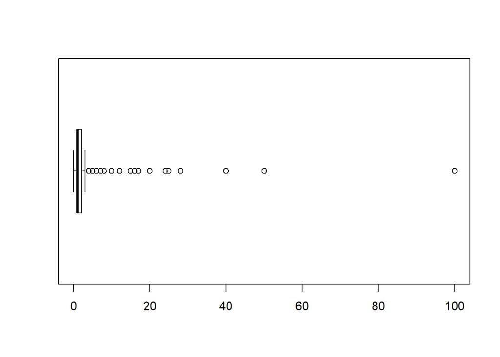

## Do you remember how old you were the very first time you had anal or vaginal sex? (ACAGE_101)

|  | n | Percent |
| --- | --- | --- |
| Yes | 1226 | 79 |
| No | 317 | 21 |

## That first time you had anal or vaginal sex, was it with a man or a woman? (ACSX1MW_101)

|  | n | Percent |
| --- | --- | --- |
| Man | 887 | 58 |
| Woman | 652 | 42 |

## How old were you the very first time you had anal or vaginal sex? (acagen_101)

|  | n | Percent |
| --- | --- | --- |
| 16 | 161 | 13.24 |
| 15 | 128 | 10.53 |
| 14 | 128 | 10.53 |
| 12 | 121 | 9.95 |
| 13 | 114 | 9.38 |
| 17 | 107 | 8.80 |
| 18 | 89 | 7.32 |
| 19 | 59 | 4.85 |
| 11 | 43 | 3.54 |
| 10 | 38 | 3.12 |
| 21 | 35 | 2.88 |
| 20 | 35 | 2.88 |
| 9 | 26 | 2.14 |
| 22 | 19 | 1.56 |
| 8 | 19 | 1.56 |
| 7 | 14 | 1.15 |
| 23 | 12 | 0.99 |
| 25 | 9 | 0.74 |
| 5 | 9 | 0.74 |
| 24 | 8 | 0.66 |
| 6 | 6 | 0.49 |
| 30 | 4 | 0.33 |
| 26 | 4 | 0.33 |
| 44 | 3 | 0.25 |
| 35 | 3 | 0.25 |
| 28 | 3 | 0.25 |
| 4 | 3 | 0.25 |
| 42 | 2 | 0.16 |
| 40 | 2 | 0.16 |
| 3 | 2 | 0.16 |
| 45 | 1 | 0.08 |
| 43 | 1 | 0.08 |
| 38 | 1 | 0.08 |
| 36 | 1 | 0.08 |
| 34 | 1 | 0.08 |
| 33 | 1 | 0.08 |
| 32 | 1 | 0.08 |
| 31 | 1 | 0.08 |
| 29 | 1 | 0.08 |
| 27 | 1 | 0.08 |

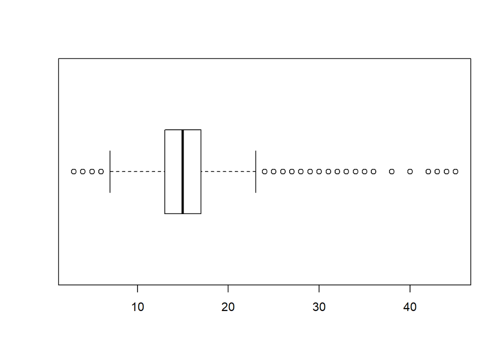

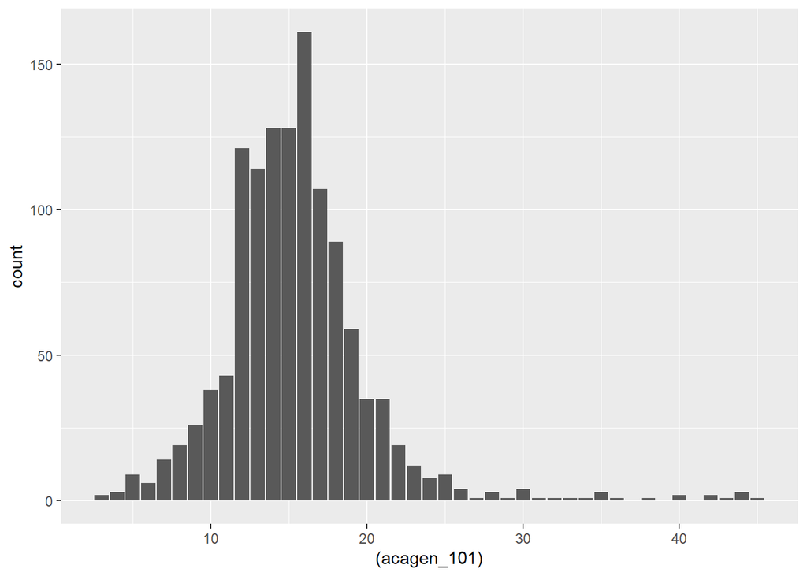

## How many men have you had sex with in the last 6 months? Include only men with whom you had anal sex (either as a top or a bottom). It doesn’t matter whether a condom was used, or whether there was ejaculation. Please do not include transgender partners. (ACMN_101)

|  | n | Percent |
| --- | --- | --- |
| 2 | 303 | 19.56 |
| 1 | 296 | 19.11 |
| 3 | 263 | 16.98 |
| 4 | 148 | 9.55 |
| 5 | 131 | 8.46 |
| 6 | 71 | 4.58 |
| 10 | 61 | 3.94 |
| 7 | 42 | 2.71 |
| 8 | 40 | 2.58 |
| 0 | 38 | 2.45 |
| 20 | 31 | 2.00 |
| 15 | 19 | 1.23 |
| 12 | 18 | 1.16 |
| 9 | 11 | 0.71 |
| 30 | 9 | 0.58 |
| 25 | 9 | 0.58 |
| 40 | 8 | 0.52 |
| 13 | 8 | 0.52 |
| 35 | 4 | 0.26 |
| 11 | 4 | 0.26 |
| 100 | 3 | 0.19 |
| 60 | 3 | 0.19 |
| 50 | 3 | 0.19 |
| 24 | 3 | 0.19 |
| 200 | 2 | 0.13 |
| 21 | 2 | 0.13 |
| 18 | 2 | 0.13 |
| 17 | 2 | 0.13 |
| 16 | 2 | 0.13 |
| 14 | 2 | 0.13 |
| 300 | 1 | 0.06 |
| 90 | 1 | 0.06 |
| 85 | 1 | 0.06 |
| 67 | 1 | 0.06 |
| 55 | 1 | 0.06 |
| 52 | 1 | 0.06 |
| 45 | 1 | 0.06 |
| 37 | 1 | 0.06 |
| 36 | 1 | 0.06 |
| 28 | 1 | 0.06 |
| 27 | 1 | 0.06 |

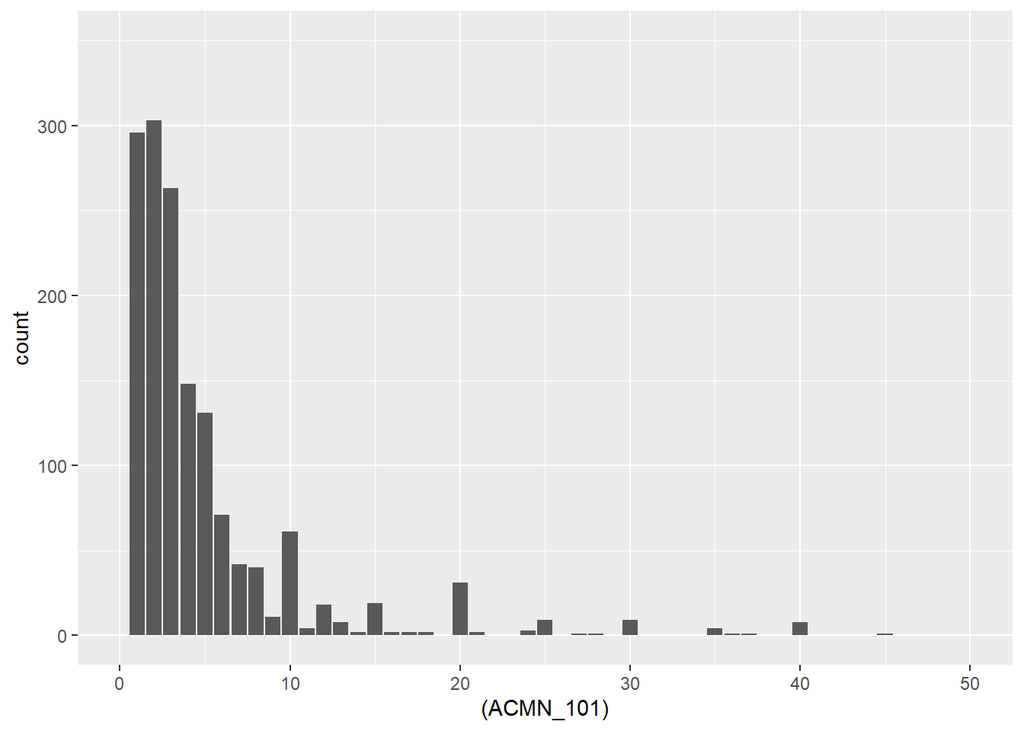

## How many women have you had sex with in the last 6 months? Include only women with whom you had vaginal or anal sex. It doesn’t matter whether a condom was used, or whether there was ejaculation. Please do not include transgender partners.(ACFN_101)

|  | n | Percent |
| --- | --- | --- |
| 0 | 902 | 58.27 |
| 1 | 209 | 13.50 |
| 2 | 158 | 10.21 |
| 3 | 80 | 5.17 |
| 4 | 54 | 3.49 |
| 5 | 39 | 2.52 |
| 6 | 28 | 1.81 |
| 8 | 15 | 0.97 |
| 7 | 11 | 0.71 |
| 10 | 10 | 0.65 |
| 12 | 6 | 0.39 |
| 20 | 5 | 0.32 |
| 15 | 5 | 0.32 |
| 9 | 5 | 0.32 |
| 11 | 4 | 0.26 |
| 13 | 3 | 0.19 |
| 40 | 2 | 0.13 |
| 30 | 2 | 0.13 |
| 999 | 1 | 0.06 |
| 300 | 1 | 0.06 |
| 60 | 1 | 0.06 |
| 48 | 1 | 0.06 |
| 35 | 1 | 0.06 |
| 27 | 1 | 0.06 |
| 26 | 1 | 0.06 |
| 24 | 1 | 0.06 |
| 18 | 1 | 0.06 |
| 14 | 1 | 0.06 |

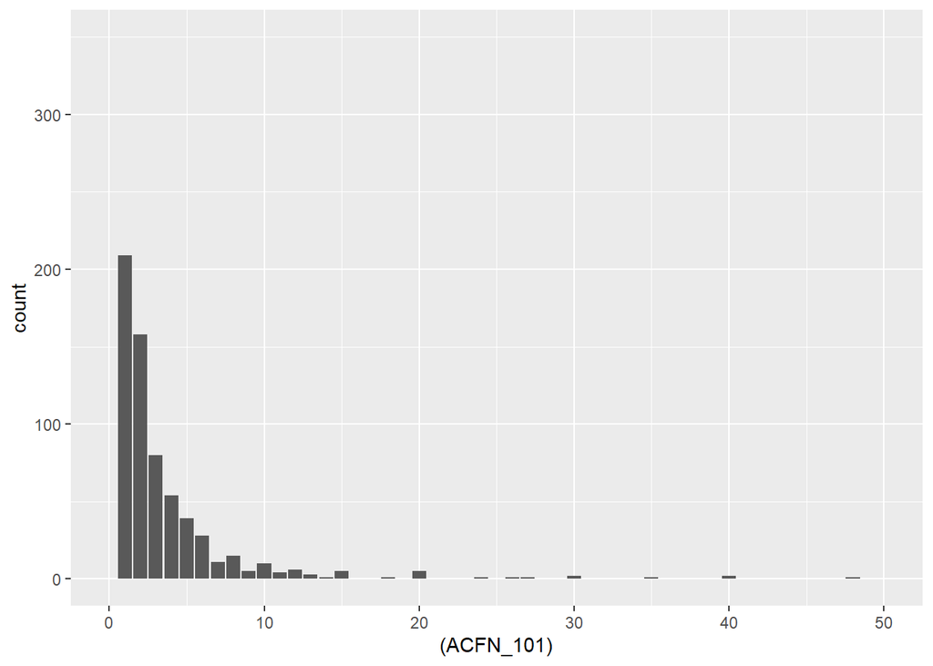

## How many transgender partners have you had sex with in the last 6 months that you consider to be female?(ACTGFN_101)

|  | n | Percent |
| --- | --- | --- |
| 0 | 1297 | 83.84 |
| 1 | 117 | 7.56 |
| 2 | 59 | 3.81 |
| 3 | 26 | 1.68 |
| 4 | 14 | 0.90 |
| 5 | 10 | 0.65 |
| 10 | 5 | 0.32 |
| 6 | 4 | 0.26 |
| 11 | 3 | 0.19 |
| 20 | 2 | 0.13 |
| 9 | 2 | 0.13 |
| 3000 | 1 | 0.06 |
| 101 | 1 | 0.06 |
| 60 | 1 | 0.06 |
| 19 | 1 | 0.06 |
| 18 | 1 | 0.06 |
| 12 | 1 | 0.06 |
| 8 | 1 | 0.06 |
| 7 | 1 | 0.06 |

|  | n | Percent |
| --- | --- | --- |
| 0 | 1232 | 79.64 |
| 1 | 140 | 9.05 |
| 2 | 70 | 4.52 |
| 3 | 49 | 3.17 |
| 5 | 14 | 0.90 |
| 4 | 13 | 0.84 |
| 6 | 9 | 0.58 |
| 8 | 5 | 0.32 |
| 10 | 3 | 0.19 |
| 718 | 1 | 0.06 |
| 50 | 1 | 0.06 |
| 33 | 1 | 0.06 |
| 31 | 1 | 0.06 |
| 25 | 1 | 0.06 |
| 22 | 1 | 0.06 |
| 20 | 1 | 0.06 |
| 18 | 1 | 0.06 |
| 12 | 1 | 0.06 |
| 11 | 1 | 0.06 |
| 9 | 1 | 0.06 |
| 7 | 1 | 0.06 |

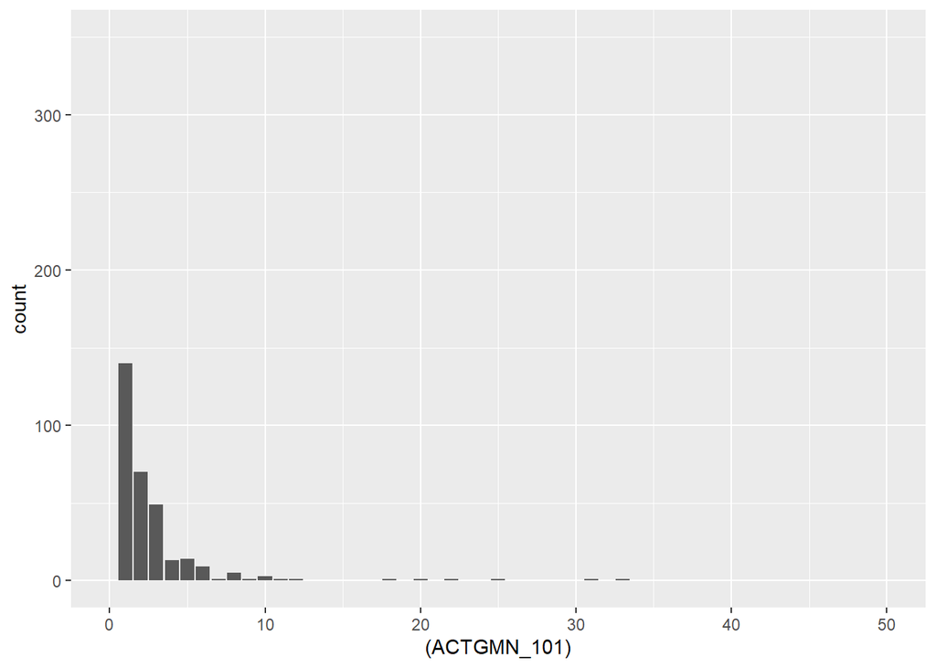

## Of the men you had anal sex with in the last 6 months, how many were new partners, that is, you had sex with them for the first time within the last 6 months?(ACMNWN_101)

|  | n | Percent |
| --- | --- | --- |
| 1 | 445 | 29.65 |
| 2 | 280 | 18.65 |
| 0 | 240 | 15.99 |
| 3 | 173 | 11.53 |
| 4 | 88 | 5.86 |
| 5 | 66 | 4.40 |
| 6 | 46 | 3.06 |
| 10 | 41 | 2.73 |
| 7 | 26 | 1.73 |
| 8 | 16 | 1.07 |
| 20 | 12 | 0.80 |
| 15 | 10 | 0.67 |
| 12 | 9 | 0.60 |
| 11 | 7 | 0.47 |
| 25 | 6 | 0.40 |
| 9 | 6 | 0.40 |
| 30 | 4 | 0.27 |
| 17 | 4 | 0.27 |
| 40 | 3 | 0.20 |
| 13 | 3 | 0.20 |
| 28 | 2 | 0.13 |
| 24 | 2 | 0.13 |
| 19 | 2 | 0.13 |
| 150 | 1 | 0.07 |
| 100 | 1 | 0.07 |
| 90 | 1 | 0.07 |
| 87 | 1 | 0.07 |
| 55 | 1 | 0.07 |
| 50 | 1 | 0.07 |
| 37 | 1 | 0.07 |
| 36 | 1 | 0.07 |
| 18 | 1 | 0.07 |
| 14 | 1 | 0.07 |

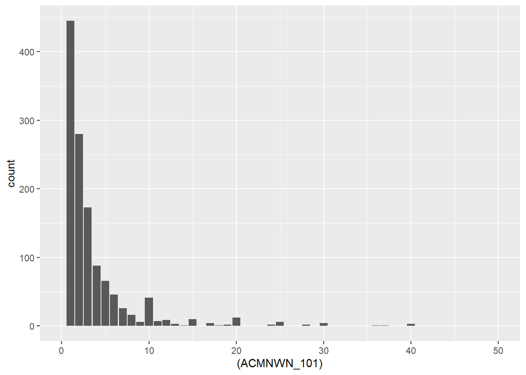

|  | n | Percent |
| --- | --- | --- |
| 1 | 216 | 33.86 |
| 0 | 148 | 23.20 |
| 2 | 134 | 21.00 |
| 3 | 53 | 8.31 |
| 4 | 23 | 3.61 |
| 7 | 13 | 2.04 |
| 6 | 12 | 1.88 |
| 5 | 12 | 1.88 |
| 15 | 4 | 0.63 |
| 10 | 3 | 0.47 |
| 8 | 3 | 0.47 |
| 12 | 2 | 0.31 |
| 11 | 2 | 0.31 |
| 9 | 2 | 0.31 |
| 100 | 1 | 0.16 |
| 48 | 1 | 0.16 |
| 44 | 1 | 0.16 |
| 40 | 1 | 0.16 |
| 35 | 1 | 0.16 |
| 27 | 1 | 0.16 |
| 25 | 1 | 0.16 |
| 23 | 1 | 0.16 |
| 22 | 1 | 0.16 |
| 20 | 1 | 0.16 |
| 19 | 1 | 0.16 |

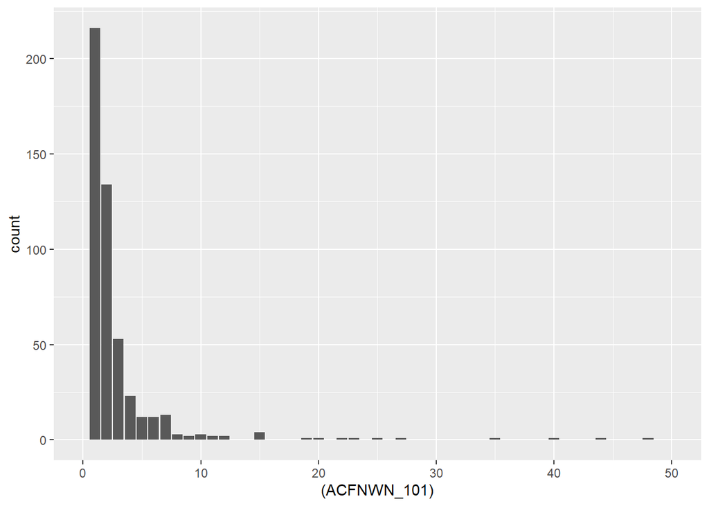

## How many transgender partners have you had sex with in the last 6 months that you consider to be something other than male or female? (ACTGOTN_101)

|  | n | Percent |
| --- | --- | --- |
| 0 | 1421 | 91.86 |
| 1 | 59 | 3.81 |
| 2 | 27 | 1.75 |
| 3 | 16 | 1.03 |
| 5 | 7 | 0.45 |
| 6 | 4 | 0.26 |
| 4 | 3 | 0.19 |
| 8 | 2 | 0.13 |
| 1222 | 1 | 0.06 |
| 1111 | 1 | 0.06 |
| 90 | 1 | 0.06 |
| 50 | 1 | 0.06 |
| 20 | 1 | 0.06 |
| 12 | 1 | 0.06 |
| 10 | 1 | 0.06 |
| 7 | 1 | 0.06 |

## Of the transgender partners you had vaginal or anal sex with in the last 6 months, how many were new partners, that is, you had sex with them for the first time within the last 6 months? (ACTGNWN_101)

|  | n | Percent |
| --- | --- | --- |
| 1 | 133 | 35.56 |
| 2 | 82 | 21.93 |
| 0 | 63 | 16.84 |
| 3 | 32 | 8.56 |
| 4 | 20 | 5.35 |
| 5 | 13 | 3.48 |
| 6 | 8 | 2.14 |
| 8 | 4 | 1.07 |
| 10 | 3 | 0.80 |
| 7 | 3 | 0.80 |
| 15 | 2 | 0.53 |
| 12 | 2 | 0.53 |
| 1111 | 1 | 0.27 |
| 100 | 1 | 0.27 |
| 60 | 1 | 0.27 |
| 36 | 1 | 0.27 |
| 22 | 1 | 0.27 |
| 20 | 1 | 0.27 |
| 14 | 1 | 0.27 |
| 13 | 1 | 0.27 |
| 11 | 1 | 0.27 |

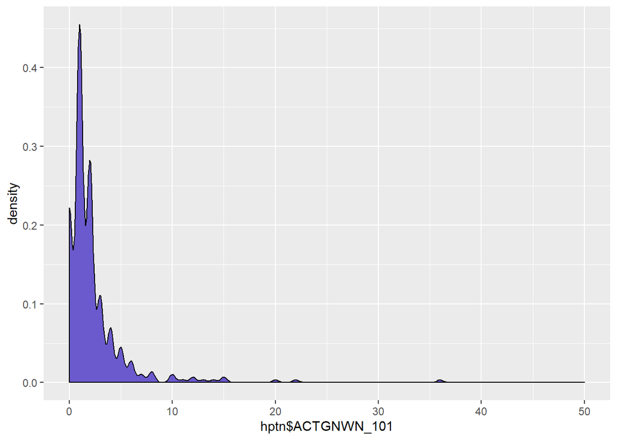

## Of all the sex that you had with transgender partners in the last 6 months, how often was this sex without a condom? (without a condom" means not using a condom for even some of the time while you had sex.) (ACTGNCN_101)

|  | n | Percent |
| --- | --- | --- |
| Sometimes | 114 | 30 |
| Always | 75 | 20 |
| Never | 68 | 18 |
| Rarely | 61 | 16 |
| Often | 58 | 15 |

## A little while ago you were asked to report the number of women, who were not transgender, who you had sex with in the last six months. Then you were asked to report the number of transgender partners you consider to be female who you had sex with in the last six months. Thinking of ALL your female partners from the last 6 months (whether they’re transgender or not), do these partners know that you also have sex with men? (ACWKNWM_101)

|  | n | Percent |
| --- | --- | --- |
| No, none do | 274 | 41 |
| Yes, all do | 158 | 24 |
| Some do, others do not | 138 | 21 |
| Dont know | 100 | 15 |

## Of the men (including transgender partners thought of as men) you had anal sex with in the last 6 months, how many did you top, where your penis was in his anus? (ACMTPN_101)

|  | n | Percent |
| --- | --- | --- |
| 1 | 362 | 23.96 |
| 2 | 276 | 18.27 |
| 0 | 219 | 14.49 |
| 3 | 206 | 13.63 |
| 4 | 120 | 7.94 |
| 5 | 80 | 5.29 |
| 6 | 59 | 3.90 |
| 10 | 34 | 2.25 |
| 7 | 24 | 1.59 |
| 8 | 19 | 1.26 |
| 9 | 14 | 0.93 |
| 20 | 12 | 0.79 |
| 15 | 12 | 0.79 |
| 12 | 12 | 0.79 |
| 13 | 8 | 0.53 |
| 30 | 6 | 0.40 |
| 11 | 5 | 0.33 |
| 35 | 4 | 0.26 |
| 18 | 4 | 0.26 |
| 14 | 4 | 0.26 |
| 40 | 3 | 0.20 |
| 25 | 3 | 0.20 |
| 24 | 3 | 0.20 |
| 21 | 3 | 0.20 |
| 50 | 2 | 0.13 |
| 28 | 2 | 0.13 |
| 200 | 1 | 0.07 |
| 90 | 1 | 0.07 |
| 85 | 1 | 0.07 |
| 64 | 1 | 0.07 |
| 58 | 1 | 0.07 |
| 55 | 1 | 0.07 |
| 52 | 1 | 0.07 |
| 51 | 1 | 0.07 |
| 46 | 1 | 0.07 |
| 45 | 1 | 0.07 |
| 33 | 1 | 0.07 |
| 22 | 1 | 0.07 |
| 19 | 1 | 0.07 |
| 17 | 1 | 0.07 |
| 16 | 1 | 0.07 |

[figure not shown]

## Of the men (including transgender partners thought of as men), that you “topped” in the last 6 months, how many did you “top” without a condom? By without a condom we mean not using a condom for even some of the time while you had sex. (ACMTPCN_101)

|  | n | Percent |
| --- | --- | --- |
| 1 | 486 | 37.70 |
| 2 | 249 | 19.32 |
| 3 | 152 | 11.79 |
| 0 | 148 | 11.48 |
| 4 | 70 | 5.43 |
| 5 | 58 | 4.50 |
| 6 | 28 | 2.17 |
| 10 | 15 | 1.16 |
| 8 | 14 | 1.09 |
| 7 | 14 | 1.09 |
| 20 | 8 | 0.62 |
| 12 | 7 | 0.54 |
| 40 | 4 | 0.31 |
| 30 | 4 | 0.31 |
| 13 | 4 | 0.31 |
| 11 | 4 | 0.31 |
| 9 | 4 | 0.31 |
| 25 | 3 | 0.23 |
| 18 | 3 | 0.23 |
| 90 | 2 | 0.16 |
| 35 | 2 | 0.16 |
| 85 | 1 | 0.08 |
| 52 | 1 | 0.08 |
| 26 | 1 | 0.08 |
| 23 | 1 | 0.08 |
| 22 | 1 | 0.08 |
| 21 | 1 | 0.08 |
| 19 | 1 | 0.08 |
| 17 | 1 | 0.08 |
| 15 | 1 | 0.08 |
| 14 | 1 | 0.08 |

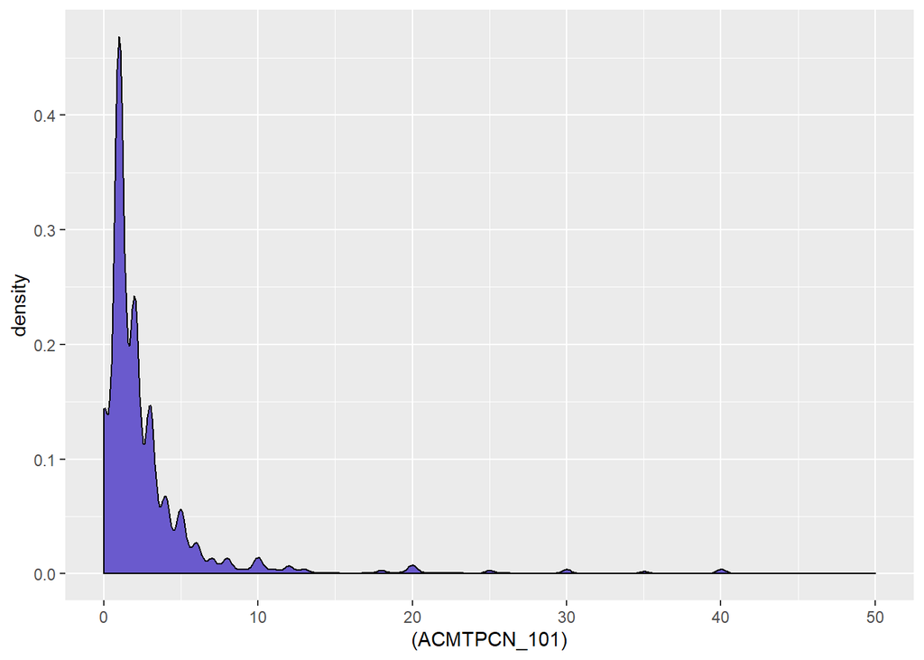

## Of the men (including transgender partners thought of as men) you had anal sex with in the last 6 months, with how many were you the bottom, where his penis was in your anus? (ACMBTN_101)

|  | n | Percent |
| --- | --- | --- |
| 0 | 600 | 39.87 |
| 1 | 340 | 22.59 |
| 2 | 222 | 14.75 |
| 3 | 105 | 6.98 |
| 4 | 63 | 4.19 |
| 5 | 59 | 3.92 |
| 6 | 20 | 1.33 |
| 8 | 14 | 0.93 |
| 7 | 14 | 0.93 |
| 10 | 13 | 0.86 |
| 9 | 9 | 0.60 |
| 15 | 8 | 0.53 |
| 12 | 6 | 0.40 |
| 30 | 4 | 0.27 |
| 25 | 4 | 0.27 |
| 20 | 4 | 0.27 |
| 16 | 3 | 0.20 |
| 13 | 2 | 0.13 |
| 11 | 2 | 0.13 |
| 200 | 1 | 0.07 |
| 180 | 1 | 0.07 |
| 100 | 1 | 0.07 |
| 58 | 1 | 0.07 |
| 55 | 1 | 0.07 |
| 50 | 1 | 0.07 |
| 40 | 1 | 0.07 |
| 39 | 1 | 0.07 |
| 37 | 1 | 0.07 |
| 36 | 1 | 0.07 |
| 32 | 1 | 0.07 |
| 19 | 1 | 0.07 |
| 14 | 1 | 0.07 |

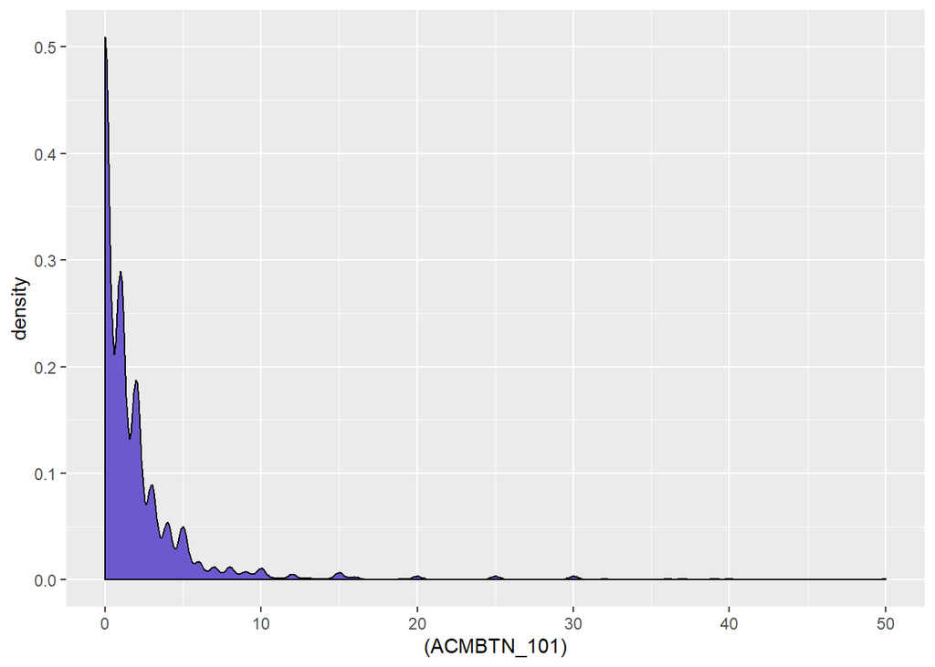

## Of the men (including transgender partners thought of as men) with whom you were the “bottom” in the last 6 months, with how many were you the “bottom” without a condom? By without a condom we mean not using a condom for even some of the time while you had sex. (ACMBTCN_101)

|  | n | Percent |
| --- | --- | --- |
| 1 | 397 | 44.01 |
| 2 | 176 | 19.51 |
| 0 | 125 | 13.86 |
| 3 | 80 | 8.87 |
| 4 | 39 | 4.32 |
| 5 | 28 | 3.10 |
| 10 | 11 | 1.22 |
| 7 | 9 | 1.00 |
| 6 | 9 | 1.00 |
| 8 | 7 | 0.78 |
| 30 | 3 | 0.33 |
| 25 | 2 | 0.22 |
| 20 | 2 | 0.22 |
| 9 | 2 | 0.22 |
| 180 | 1 | 0.11 |
| 80 | 1 | 0.11 |
| 70 | 1 | 0.11 |
| 54 | 1 | 0.11 |
| 40 | 1 | 0.11 |
| 39 | 1 | 0.11 |
| 36 | 1 | 0.11 |
| 23 | 1 | 0.11 |
| 18 | 1 | 0.11 |
| 17 | 1 | 0.11 |
| 14 | 1 | 0.11 |
| 12 | 1 | 0.11 |

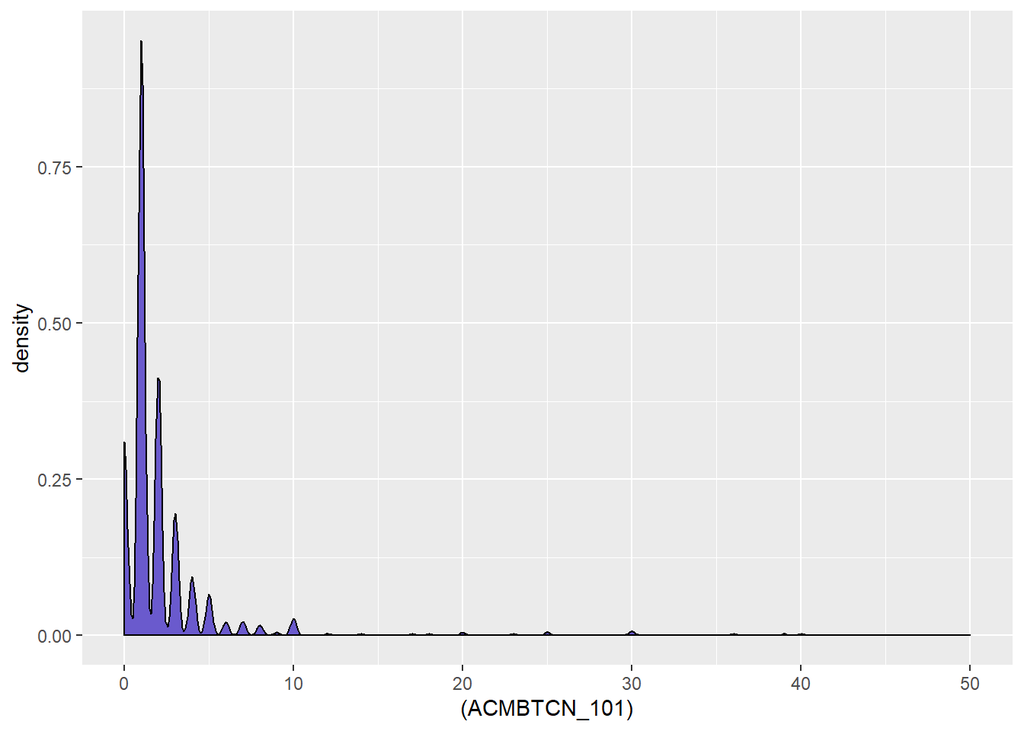